# Saudi Arabia Real Estate (AQAR), Rental house for Riyadh, Jeddah, Dammam, and Alkhobar Data Analysis

#### Programmatic assessment

```python
data.info()
```

```
<class 'pandas.core.frame.DataFrame'>
RangeIndex: 3718 entries, 0 to 3717
Data columns (total 24 columns):
 #   Column        Non-Null Count  Dtype
---  ------        --------------  -----
 0   city          3718 non-null   object
 1   district      3718 non-null   object
 2   front         3718 non-null   object
 3   size          3718 non-null   int64
 4   property_age  3718 non-null   int64
 5   bedrooms      3718 non-null   int64
 6   bathrooms     3718 non-null   int64
 7   livingrooms   3718 non-null   int64
 8   kitchen       3718 non-null   int64
 9   garage        3718 non-null   int64
```

[output cut: 16 more lines]

```python
#high-level overview of data shape and composition
print(data.shape)
print(data.dtypes)
```

```
(3718, 24)
city            object
district        object
front           object
size             int64
property_age     int64
bedrooms         int64
bathrooms        int64
livingrooms      int64
kitchen          int64
garage           int64
driver_room      int64
maid_room        int64
furnished        int64
ac               int64
roof             int64
pool             int64
frontyard        int64
basement         int64
duplex           int64
stairs           int64
elevator         int64
fireplace        int64
price            int64
details         object
dtype: object
```

```python
data.columns
```

```
Index(['city', 'district', 'front', 'size', 'property_age', 'bedrooms',
       'bathrooms', 'livingrooms', 'kitchen', 'garage', 'driver_room',
       'maid_room', 'furnished', 'ac', 'roof', 'pool', 'frontyard', 'basement',
       'duplex', 'stairs', 'elevator', 'fireplace', 'price', 'details'],
      dtype='object')
```

```python
# descriptive statistics for numeric variables
print(data.describe())
```

```
               size  property_age     bedrooms    bathrooms  livingrooms  \
count   3718.000000   3718.000000  3718.000000  3718.000000  3718.000000
mean     390.968531      5.064820     5.083916     4.606509     2.243948
std     1565.056135      7.590427     1.230040     0.703449     0.916436
min        1.000000      0.000000     1.000000     1.000000     1.000000
25%      280.000000      0.000000     4.000000     4.000000     2.000000
50%      330.000000      2.000000     5.000000     5.000000     2.000000
75%      400.000000      7.000000     6.000000     5.000000     3.000000
max    95000.000000     36.000000     7.000000     5.000000     5.000000

           kitchen       garage  driver_room    maid_room    furnished  \
count  3718.000000  3718.000000  3718.000000  3718.000000  3718.000000
mean      0.909360     0.802044     0.495697     0.795320     0.123453
std       0.287135     0.398512     0.500049     0.403522     0.329001
min       0.000000     0.000000     0.000000     0.000000     0.000000
25%       1.000000     1.000000     0.000000     1.000000     0.000000
50%       1.000000     1.000000     0.000000     1.000000     0.000000
75%       1.000000     1.000000     1.000000     1.000000     0.000000
max       1.000000     1.000000     1.000000     1.000000     1.000000

                ac         roof         pool    frontyard     basement  \
count  3718.000000  3718.000000  3718.000000  3718.000000  3718.000000
mean      0.560785     0.521517     0.162453     0.802582     0.034158
std       0.496358     0.499604     0.368915     0.398104     0.181660
min       0.000000     0.000000     0.000000     0.000000     0.000000
25%       0.000000     0.000000     0.000000     1.000000     0.000000
50%       1.000000     1.000000     0.000000     1.000000     0.000000
75%       1.000000     1.000000     0.000000     1.000000     0.000000
max       1.000000     1.000000     1.000000     1.000000     1.000000

            duplex       stairs     elevator    fireplace         price
count  3718.000000  3718.000000  3718.000000  3718.000000  3.718000e+03
mean      0.499462     0.814416     0.080958     0.181280  8.738797e+04
std       0.500067     0.388823     0.272807     0.385302  7.063470e+04
min       0.000000     0.000000     0.000000     0.000000  1.000000e+03
25%       0.000000     1.000000     0.000000     0.000000  5.500000e+04
50%       0.000000     1.000000     0.000000     0.000000  7.000000e+04
75%       1.000000     1.000000     0.000000     0.000000  1.000000e+05
max       1.000000     1.000000     1.000000     1.000000  1.700000e+06
```

```python
#Check the city unique valuse , in order to check if the values is correctly spelt
data.city.value_counts()
```

```
 الخبر     976
 الرياض    960
 الدمام    894
 جدة       888
Name: city, dtype: int64
```

```python
data.front.value_counts()
```

```
شمال         917
شرق          776
غرب          771
جنوب         739
شمال شرقي    147
جنوب شرقي    141
جنوب غربي    112
شمال غربي     83
3 شوارع       23
4 شوارع        9
Name: front, dtype: int64
```

```python
data.district.unique()
```

```
array(['   حي العارض ', '   حي القادسية ', '   حي المعيزلة ',
       '   حي العليا ', '   حي الازدهار ', '   حي المهدية ',
       '   حي الحزم ', '   حي الصحافة ', '   حي بنبان ',
       '   حي النسيم الغربي ', '   حي النرجس ', '   حي الملز ',
       '   حي الياسمين ', '   حي المونسية ', '   حي السليمانية ',
       '   حي العقيق ', '   حي المرسلات ', '   حي الرحمانية ',
       '   حي الرمال ', '   حي طويق ', '   حي الملقا ', '   حي النزهة ',
       '   حي الربيع ', '   حي ظهرة لبن ', '   حي الروضة ', '   حي عكاظ ',
       '   حي الورود ', '   حي الفيحاء ', '   حي النموذجية ',
       '   حي الربوة ', '   حي القيروان ', '   حي عليشة ',
       '   حي الملك فيصل ', '   حي حطين ', '   حي المناخ ',
       '   حي البديعة ', '   حي الشهداء ', '   حي قرطبة ',
       '   حي العريجاء الغربية ', '   حي النفل ', '   حي القدس ',
       '   حي الملك فهد ', '   حي العزيزية ', '   حي الواحة ',
       '   حي النسيم الشرقي ', '   حي المصيف ', '   حي الزهرة ',
       '   حي اليرموك ', '   حي الملك عبدالله ', '   حي المحمدية ',
       '   حي ام سليم ', '   حي الاندلس ', '   حي المروج ',
       '   حي المؤتمرات ', '   حي الرائد ', '   حي الروابي ',
       '   حي اشبيلية ', '   حي الوشام ', '   حي الخليج ', '   حي الشرق ',
       '   حي الجزيرة ', '   حي عرقة ', '   حي المنار ', '   حي النخيل ',
       '   حي الوادي ', '   حي التعاون ', '   حي غرناطة ',
       '   حي العريجاء الوسطى ', '   حي الدار البيضاء ', '   حي الهدا ',
       '   حي السويدي ', '   حي الندى ', '   حي ام الحمام الشرقي ',
       '   حي ظهرة البديعة ', '   حي السفارات ', '   حي الجنادرية ',
       '   حي جرير ', '   حي السعادة ', '   حي أحد ',
       '   حي السويدي الغربي ', '   حي ام الحمام الغربي ',
       '   حي مطار الملك خالد الدولي ', '   حي الصفا ', '   حي بدر ',
       '   حي النظيم ', '   حي ديراب ', '   حي النهضة ', '   حي الشفا ',
       '   حي شبرا ', '   حي الضباط ', '   حي منفوحة الجديدة ',
       '   حي الخزامى ', '   حي الحمراء ', '   حي لبن ', '   حي السلام ',
       '   حي سلطانة ', '   حي الملك عبدالعزيز ', '   حي الاسكان ',
       '   حي الخالدية ', '   حي الرفيعة ', '   حي العريجاء ',
       '   حي غبيرة ', '   حي الوزارات ',
       '   حي المدينة الصناعية الجديدة ', '   حي الفلاح ',
       '   حي الحائر ', '   حي المنصورة ', '   حي طيبة ', '   حي الزمرد ',
       '   حي الياقوت ', '   حي البساتين ', '   حي الزهراء ',
       '   حي بريمان ', '   حي الشاطئ ', '   حي ابحر الشمالية ',
       '   حي النعيم ', '   حي الصالحية ', '   حي المنتزه ',
       '   حي الرياض ', '   حي الصوارى ', '   حي ابحر الجنوبية ',
       '   حي المرجان ', '   حي السامر ', '   حي السلامة ',
       '   حي ام حبلين ', '   حي الرحاب ', '   حي المروة ',
       '   حي مشرفة ', '   حي الفيصلية ', '   حي الاجاويد ',
       '   حي الكوثر ', '   حي الفردوس ', '   حي الامواج ',
       '   حي الشراع ', '   حي الرويس ', '   حي البوادي ',
       '   حي الريان ', '   حي بني مالك ', '   حي الحمدانية ',
       '   حي اللؤلؤ ', '   حي الاصالة ', '   حي البغدادية الشرقية ',
       '   حي الجامعة ', '   حي مريخ ', '   حي الامير فواز الشمالي ',
       '   حي ضاحية الملك فهد ', '   حي السيف ', '   حي الشعلة ',
       '   حي الخالدية الشمالية ', '   حي الفرسان ', '   حي الاثير ',
       '   حي المدينة الصناعية الثانية ', '   حي الجوهرة ',
       '   حي الشاطئ الغربي ', '   حي الشاطئ الشرقي ', '   حي الأمل ',
       '   حي الانوار ', '   حي النورس ', '   حي المزروعية ',
       '   حي جامعة الدمام ', '   حي الحزام الاخضر ', '   حي الصواري ',
       '   حي الراكة الجنوبية ', '   حي التحلية ', '   حي البحيرة ',
       '   حي مدينة العمال ', '   حي الكورنيش ',
       '   حي المدينة الرياضية ', '   حي الجسر ', '   حي السفن ',
       '   حي الحزام الذهبي ', '   حي العقربية ', '   حي الخبر الشمالية ',
       '   حي الثقبة '], dtype=object)
```

```python
data.district.value_counts()
```

```
   حي ضاحية الملك فهد       173
   حي التحلية               149
   حي اللؤلؤ                149
   حي الصواري               149
   حي العارض                137
                           ...
   حي العريجاء                1
   حي السفارات                1
   حي الوزارات                1
   حي السفن                   1
   حي البغدادية الشرقية       1
Name: district, Length: 174, dtype: int64
```

```python
data.district.sample(10)
```

```
3408            حي التحلية
1514            حي الياقوت
998              حي الشاطئ
2714                حي بدر
1319             حي الشاطئ
3462             حي اللؤلؤ
2667            حي المنتزه
249               حي الملز
801              حي الرمال
2947       حي مدينة العمال
Name: district, dtype: object
```

```python
#Check null values
data.isnull().sum() #There is no null values in the variables of our interest
```

```
city             0
district         0
front            0
size             0
property_age     0
bedrooms         0
bathrooms        0
livingrooms      0
kitchen          0
garage           0
driver_room      0
maid_room        0
furnished        0
ac               0
roof             0
pool             0
frontyard        0
basement         0
duplex           0
stairs           0
elevator         0
fireplace        0
price            0
details         80
dtype: int64
```

```python
#Check any duplicates
data.duplicated().sum()
```

```
2197
```

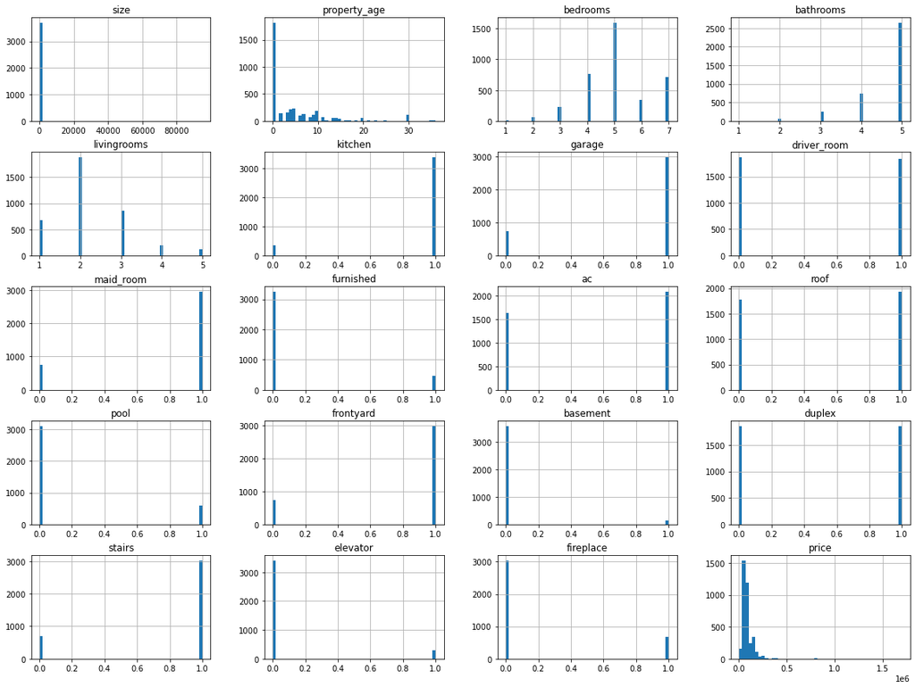

```python
#The distribution of the features values
data.hist(bins=50, figsize=(20,15));
```

```python
#Data Description
data.describe()
```

|  | size | property_age | bedrooms | bathrooms | livingrooms | kitchen | garage | driver_room | maid_room | furnished | ac | roof | pool | frontyard | basement | duplex | stairs | elevator | fireplace | price |
| --- | --- | --- | --- | --- | --- | --- | --- | --- | --- | --- | --- | --- | --- | --- | --- | --- | --- | --- | --- | --- |
| count | 3718.000000 | 3718.000000 | 3718.000000 | 3718.000000 | 3718.000000 | 3718.000000 | 3718.000000 | 3718.000000 | 3718.000000 | 3718.000000 | 3718.000000 | 3718.000000 | 3718.000000 | 3718.000000 | 3718.000000 | 3718.000000 | 3718.000000 | 3718.000000 | 3718.000000 | 3.718000e+03 |
| mean | 390.968531 | 5.064820 | 5.083916 | 4.606509 | 2.243948 | 0.909360 | 0.802044 | 0.495697 | 0.795320 | 0.123453 | 0.560785 | 0.521517 | 0.162453 | 0.802582 | 0.034158 | 0.499462 | 0.814416 | 0.080958 | 0.181280 | 8.738797e+04 |
| std | 1565.056135 | 7.590427 | 1.230040 | 0.703449 | 0.916436 | 0.287135 | 0.398512 | 0.500049 | 0.403522 | 0.329001 | 0.496358 | 0.499604 | 0.368915 | 0.398104 | 0.181660 | 0.500067 | 0.388823 | 0.272807 | 0.385302 | 7.063470e+04 |
| min | 1.000000 | 0.000000 | 1.000000 | 1.000000 | 1.000000 | 0.000000 | 0.000000 | 0.000000 | 0.000000 | 0.000000 | 0.000000 | 0.000000 | 0.000000 | 0.000000 | 0.000000 | 0.000000 | 0.000000 | 0.000000 | 0.000000 | 1.000000e+03 |
| 25% | 280.000000 | 0.000000 | 4.000000 | 4.000000 | 2.000000 | 1.000000 | 1.000000 | 0.000000 | 1.000000 | 0.000000 | 0.000000 | 0.000000 | 0.000000 | 1.000000 | 0.000000 | 0.000000 | 1.000000 | 0.000000 | 0.000000 | 5.500000e+04 |
| 50% | 330.000000 | 2.000000 | 5.000000 | 5.000000 | 2.000000 | 1.000000 | 1.000000 | 0.000000 | 1.000000 | 0.000000 | 1.000000 | 1.000000 | 0.000000 | 1.000000 | 0.000000 | 0.000000 | 1.000000 | 0.000000 | 0.000000 | 7.000000e+04 |
| 75% | 400.000000 | 7.000000 | 6.000000 | 5.000000 | 3.000000 | 1.000000 | 1.000000 | 1.000000 | 1.000000 | 0.000000 | 1.000000 | 1.000000 | 0.000000 | 1.000000 | 0.000000 | 1.000000 | 1.000000 | 0.000000 | 0.000000 | 1.000000e+05 |
| max | 95000.000000 | 36.000000 | 7.000000 | 5.000000 | 5.000000 | 1.000000 | 1.000000 | 1.000000 | 1.000000 | 1.000000 | 1.000000 | 1.000000 | 1.000000 | 1.000000 | 1.000000 | 1.000000 | 1.000000 | 1.000000 | 1.000000 | 1.700000e+06 |

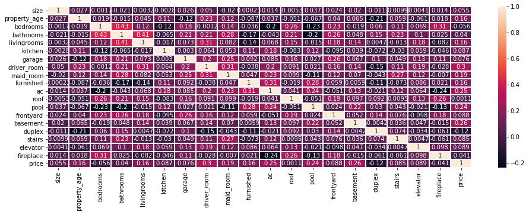

```python
plt.figure(figsize=(16,5))
sns.heatmap(data.corr(),annot=True,lw=1);
```

- Correlation analysis deals with relationships among variables. The correlation coefficient is a measure of the linear association between two variables, its value is always between -1 and +1.
- A correlation coefficient of +1 refers to that the two variables are related in a positive linear sense, -1 refers to that the two variables are related in a negative linear sense, and 0 refers to that there is no linear relationship between the two variables.
- From the above graph, we notice that the driver room, ac,pool and basement have a relatively strong positive relation with price.

### Quality issues

[output not shown]

### Tidiness issues

[output not shown]

## Cleaning Data

In this section, clean **all** of the issues we documented while assessing. its important to make a copy of the original data before cleaning.

```python
# Make copies of original pieces of data
clean_data = data.copy()
```

### Issue #1:

#### Define:

- Convert the data type of the 'city' and 'front' columns into catogrical.

#### Code

```python
# convert city, front, and clarity into categorical types
clean_data['city'] = pd.Categorical(clean_data.city)
clean_data['front'] = pd.Categorical(clean_data.front)
```

#### Test

```python
clean_data.dtypes
```

```
city            category
district          object
front           category
size               int64
property_age       int64
bedrooms           int64
bathrooms          int64
livingrooms        int64
kitchen            int64
garage             int64
driver_room        int64
maid_room          int64
furnished          int64
ac                 int64
roof               int64
pool               int64
frontyard          int64
basement           int64
duplex             int64
stairs             int64
elevator           int64
fireplace          int64
price              int64
details           object
dtype: object
```

### Issue #2:

#### Define:

- Remove the outlier point in size.

#### Code

```python
clean_data['size'].max()
```

```
95000
```

```python
clean_data.drop(clean_data.loc[clean_data['size']== clean_data['size'].max() ].index, inplace=True)
```

#### Test

```python
clean_data['size'].max()
```

```
5000
```

### Issue #3:

#### Define:

- Rename the columns ( kitchen, bedrooms','bathrooms', 'livingrooms', furnished,duplex , ac,bool ,roof ,bool ,frontyard , basement ,elevator,fireplace ) to be descriptive names.

#### Code

```python
clean_data.rename(columns={'kitchen': 'kitchen_existence','garage':'garage_existence', 'bedrooms': 'bedrooms_number','bathrooms':'bathrooms_number','livingrooms':'livingrooms_number' ,'furnished':'is_furnished' , 'duplex' :'is_duplex' ,'ac':'has_ac' , 'pool':'has_pool', 'roof':'has_roof','maid_room':'has_maid_room','driver_room':'has_driver_room','frontyard':'has_frontyard','basement':'has_basement','elevator':'has_elevator','fireplace':'has_fireplace'}, inplace=True)
```

#### Test

```python
clean_data.columns
```

```
Index(['city', 'district', 'front', 'size', 'property_age', 'bedrooms_number',
       'bathrooms_number', 'livingrooms_number', 'kitchen_existence',
       'garage_existence', 'has_driver_room', 'has_maid_room', 'is_furnished',
       'has_ac', 'has_roof', 'has_pool', 'has_frontyard', 'has_basement',
       'is_duplex', 'stairs', 'has_elevator', 'has_fireplace', 'price',
       'details'],
      dtype='object')
```

### Issue #4:

#### Define:

- Drop the duplicated rows

#### Code

```python
clean_data.drop_duplicates(inplace=True)
```

#### Test

```python
clean_data.duplicated().sum()
```

```
0
```

### Issue #5:

#### Define:

- Convert Arabic cities names and front names into English

#### Code

```python
clean_data["city"] = clean_data["city"].apply(lambda x: x.replace("الرياض", "Riyadh"))
clean_data["city"] = clean_data["city"].apply(lambda x: x.replace("جدة", "Jeddah"))
clean_data["city"] = clean_data["city"].apply(lambda x: x.replace("الدمام", "Dammam"))
clean_data["city"] = clean_data["city"].apply(lambda x: x.replace("الخبر", "Alkhobar"))
```

```python
clean_data["front"] = clean_data["front"].apply(lambda x: x.replace("شمال", "North"))
clean_data["front"] = clean_data["front"].apply(lambda x: x.replace("شرق", "West"))
clean_data["front"] = clean_data["front"].apply(lambda x: x.replace("غرب", "East"))
clean_data["front"] = clean_data["front"].apply(lambda x: x.replace("جنوب", "South"))
clean_data["front"] = clean_data["front"].apply(lambda x: x.replace("شمال شرقي", "North-Western"))
clean_data["front"] = clean_data["front"].apply(lambda x: x.replace("جنوب غربي", "South-Eastern"))
clean_data["front"] = clean_data["front"].apply(lambda x: x.replace("شمال غربي", "North-Eastern"))
clean_data["front"] = clean_data["front"].apply(lambda x: x.replace("جنوب شرقي", "South-Western"))
clean_data["front"].sample()
```

```
2787    South Eastي
Name: front, dtype: category
Categories (10, object): ['3 شوارع', '4 شوارع', 'South', 'South Westي', ..., 'North', 'North Westي', 'North Eastي', 'East']
```

#### Test

```python
clean_data.city.value_counts()
```

```
 Riyadh      904
 Jeddah      410
 Dammam      123
 Alkhobar     83
Name: city, dtype: int64
```

```python
clean_data.front.value_counts()
```

```
North          385
West           327
East           300
South          284
North Westي     72
South Westي     46
North Eastي     38
South Eastي     36
3 شوارع         23
4 شوارع          9
Name: front, dtype: int64
```

### Issue #6:

#### Define:

- Dropp unnecessary columns which will not be used in the analysis, which are : 'details' and 'stairs'

#### Code

```python
clean_data.drop(columns=['details', 'stairs'],inplace=True)
```

#### Test

```python
clean_data.columns
```

```
Index(['city', 'district', 'front', 'size', 'property_age', 'bedrooms_number',
       'bathrooms_number', 'livingrooms_number', 'kitchen_existence',
       'garage_existence', 'has_driver_room', 'has_maid_room', 'is_furnished',
       'has_ac', 'has_roof', 'has_pool', 'has_frontyard', 'has_basement',
       'is_duplex', 'has_elevator', 'has_fireplace', 'price'],
      dtype='object')
```

### Issue #7:

#### Code

```python
clean_data['rooms_number'] = clean_data['bedrooms_number']+clean_data['bathrooms_number']+clean_data['livingrooms_number']
```

#### Test

```python
clean_data.rooms_number
```

```
0       11
1       11
2       10
3       13
4       14
        ..
2820     9
2821    14
2822    12
2823     7
2824     9
Name: rooms_number, Length: 1520, dtype: int64
```

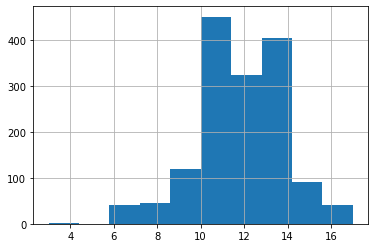

```python
clean_data.rooms_number.hist()
```

```python
clean_data.head(5)
```

|  | city | district | front | size | property_age | bedrooms_number | bathrooms_number | livingrooms_number | kitchen_existence | garage_existence | ... | has_ac | has_roof | has_pool | has_frontyard | has_basement | is_duplex | has_elevator | has_fireplace | price | rooms_number |
| --- | --- | --- | --- | --- | --- | --- | --- | --- | --- | --- | --- | --- | --- | --- | --- | --- | --- | --- | --- | --- | --- |
| 0 | Riyadh | حي العارض | North | 250 | 0 | 5 | 5 | 1 | 1 | 1 | ... | 0 | 0 | 0 | 1 | 0 | 1 | 0 | 0 | 80000 | 11 |
| 1 | Riyadh | حي القادسية | South | 370 | 0 | 4 | 5 | 2 | 1 | 1 | ... | 0 | 0 | 0 | 1 | 0 | 0 | 0 | 0 | 60000 | 11 |
| 2 | Riyadh | حي القادسية | South | 380 | 0 | 4 | 5 | 1 | 1 | 1 | ... | 0 | 1 | 0 | 1 | 0 | 0 | 0 | 0 | 60000 | 10 |
| 3 | Riyadh | حي المعيزلة | East | 250 | 0 | 5 | 5 | 3 | 0 | 1 | ... | 0 | 0 | 0 | 1 | 0 | 0 | 0 | 0 | 55000 | 13 |
| 4 | Riyadh | حي العليا | East | 400 | 11 | 7 | 5 | 2 | 1 | 1 | ... | 0 | 1 | 0 | 1 | 0 | 1 | 0 | 0 | 70000 | 14 |

5 rows × 23 columns

### Issue #8:

#### Define:

- Create bool variable to show if there are driver_room and maid_room , to exmain its relation with the price

#### Code

```python
clean_data['house_worker_facilities_existence'] = clean_data['has_maid_room'] & clean_data['has_driver_room']
```

#### Test

```python
clean_data.head()
```

|  | city | district | front | size | property_age | bedrooms_number | bathrooms_number | livingrooms_number | kitchen_existence | garage_existence | ... | has_roof | has_pool | has_frontyard | has_basement | is_duplex | has_elevator | has_fireplace | price | rooms_number | house_worker_facilities_existence |
| --- | --- | --- | --- | --- | --- | --- | --- | --- | --- | --- | --- | --- | --- | --- | --- | --- | --- | --- | --- | --- | --- |
| 0 | Riyadh | حي العارض | North | 250 | 0 | 5 | 5 | 1 | 1 | 1 | ... | 0 | 0 | 1 | 0 | 1 | 0 | 0 | 80000 | 11 | 0 |
| 1 | Riyadh | حي القادسية | South | 370 | 0 | 4 | 5 | 2 | 1 | 1 | ... | 0 | 0 | 1 | 0 | 0 | 0 | 0 | 60000 | 11 | 0 |
| 2 | Riyadh | حي القادسية | South | 380 | 0 | 4 | 5 | 1 | 1 | 1 | ... | 1 | 0 | 1 | 0 | 0 | 0 | 0 | 60000 | 10 | 1 |
| 3 | Riyadh | حي المعيزلة | East | 250 | 0 | 5 | 5 | 3 | 0 | 1 | ... | 0 | 0 | 1 | 0 | 0 | 0 | 0 | 55000 | 13 | 1 |
| 4 | Riyadh | حي العليا | East | 400 | 11 | 7 | 5 | 2 | 1 | 1 | ... | 1 | 0 | 1 | 0 | 1 | 0 | 0 | 70000 | 14 | 1 |

5 rows × 24 columns

```python
clean_data.house_worker_facilities_existence.value_counts()
```

```
1    800
0    720
Name: house_worker_facilities_existence, dtype: int64
```

## Storing Data

Save the assessed, and cleaned dataset to a CSV file named "cleand_SA_Aqar_data.csv".

```python
#This result to a high-quality and tidy CSV file).
clean_data.to_csv('cleaned_SA_Aqar_data.csv',index=False)
clean_data.columns
```

```
Index(['city', 'district', 'front', 'size', 'property_age', 'bedrooms_number',
       'bathrooms_number', 'livingrooms_number', 'kitchen_existence',
       'garage_existence', 'has_driver_room', 'has_maid_room', 'is_furnished',
       'has_ac', 'has_roof', 'has_pool', 'has_frontyard', 'has_basement',
       'is_duplex', 'has_elevator', 'has_fireplace', 'price', 'rooms_number',
       'house_worker_facilities_existence'],
      dtype='object')
```

#### Analyzing and visualizing

> we are most interested in figuring out what features are best for predicting the price of the house in the dataset.

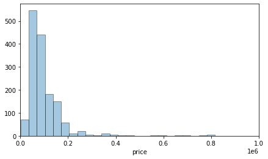

```python
#Price Distribution
plt.figure(figsize=(7,4))
plt.xlim([0.0, 1000000])
sns.distplot(clean_data['price'], kde = False,hist_kws=dict(edgecolor="k"));
```

Highest rental house price in Riyadh, Jeddah, Dammam, Khobar.

```python
def mask(str):
    mask = clean_data.loc[clean_data["city"] == str]
    print('Highest rental house price in ',str ,'is ',mask.price.max())
    return mask.price.max()
```

```python
city_list = [' Riyadh',' Jeddah',' Dammam',' Alkhobar']
Highest_rental_house_price_in_city = [mask(' Riyadh'),mask(' Jeddah'),mask(' Dammam'),mask(' Alkhobar')]
```

```
Highest rental house price in   Riyadh is  800000
Highest rental house price in   Jeddah is  1700000
Highest rental house price in   Dammam is  800000
Highest rental house price in   Alkhobar is  180000
```

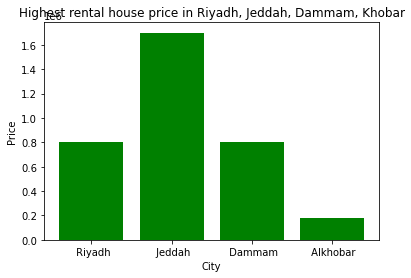

```python
import matplotlib.pyplot as plt
plt.bar(city_list, Highest_rental_house_price_in_city, color='g')
plt.xlabel('City')
plt.ylabel('Price')
plt.title('Highest rental house price in Riyadh, Jeddah, Dammam, Khobar')
plt.show()
```

- The highest rental houses price is 1700000 SAR in Jeddah, 800000 SAR in Riyadh and Dammam, and 180000 SAR in Alkhobar
- That's clear the price varies from city to city

How the price related to the size?

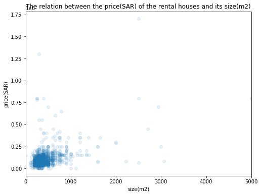

```python
plt.figure(figsize = [8, 6])
plt.scatter(data = clean_data, x = 'size', y = 'price', alpha = 1/10)
plt.title('The relation between the price(SAR) of the rental houses and its size(m2)')
plt.xlim([0, 5000])
plt.xlabel('size(m2)')
plt.ylabel('price(SAR)')
plt.show()
```

- We notice most of the size of the houses is less than 1000 m2.
- The price is increased by the increase of the house, not in all cases ,That means the price is affected by other factors , lets examine the other factors.

Does the price affected by the age of the property( does the costs of the new house higher or lower than the oldest ones with the same features ),How much does the oldest and the newest house costs ?

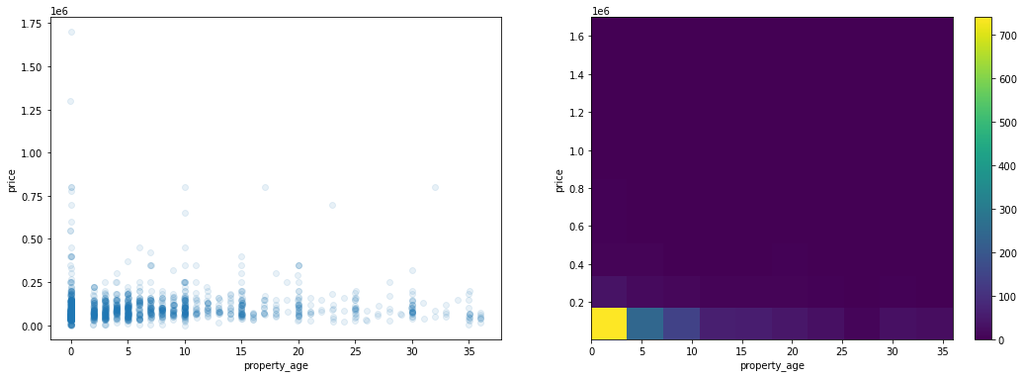

```python
# the price affected by the age of the property
plt.figure(figsize = [18, 6])

# PLOT ON LEFT
plt.subplot(1, 2, 1)
sns.regplot(data = clean_data, x = 'property_age', y = 'price', x_jitter=0.04, scatter_kws={'alpha':1/10}, fit_reg=False)
plt.xlabel('property_age')
plt.ylabel('price');

# PLOT ON RIGHT
plt.subplot(1, 2, 2)
plt.hist2d(data = clean_data, x = 'property_age', y = 'price')
plt.colorbar()
plt.xlabel('property_age')
plt.ylabel('price');
```

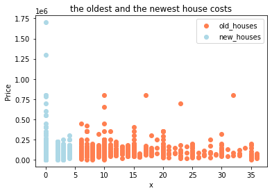

```python
#How much does the oldest and the newest house costs ?
#we will divid the data into 2 groups ,old_houses which is have property_age greater than 5 and new_houses which is have property_age less than 5
old_houses= clean_data[clean_data["property_age"] > 5][['price','property_age']]
new_houses= clean_data[clean_data["property_age"] < 5][['price','property_age']]


plt.scatter( old_houses['property_age'],old_houses['price'], c='coral')
plt.scatter( new_houses['property_age'],new_houses['price'], c='lightblue')

plt.title('the oldest and the newest house costs')
plt.xlabel('x')
plt.ylabel('Price')
plt.legend(['old_houses','new_houses'])
plt.show()
```

- Based on the above , It's clear the price is increased by the age of the property decrease.
- So the new houses cost more than the old ones

How the number of rooms(in total) affects the price of the rental house, and how does each of the bedrooms, bathrooms, livingrooms number affects the price as well?

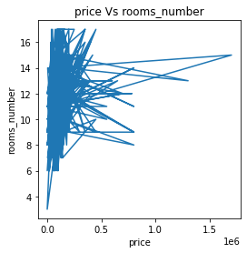

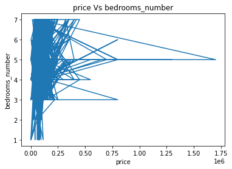

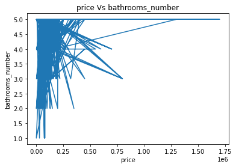

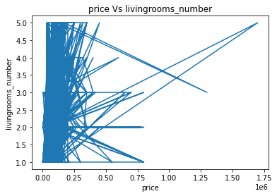

```python
plt.figure(figsize = [4, 4])

import matplotlib.pyplot as plt

plt.plot(clean_data['price'], clean_data['rooms_number'])
plt.title('price Vs rooms_number')
plt.xlabel('price')
plt.ylabel('rooms_number')
plt.show()

plt.plot(clean_data['price'], clean_data['bedrooms_number'])
plt.title('price Vs bedrooms_number')
plt.xlabel('price')
plt.ylabel('bedrooms_number')
plt.show()

plt.plot(clean_data['price'], clean_data['bathrooms_number'])
plt.title('price Vs bathrooms_number')
plt.xlabel('price')
plt.ylabel('bathrooms_number')
plt.show()

plt.plot(clean_data['price'], clean_data['livingrooms_number'])
plt.title('price Vs livingrooms_number')
plt.xlabel('price')
plt.ylabel('livingrooms_number')
plt.show()
```

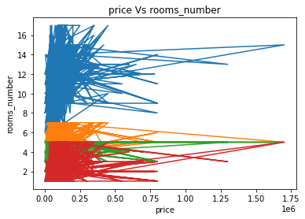

```python
import matplotlib.pyplot as plt

plt.plot(clean_data['price'], clean_data['rooms_number'])
plt.plot(clean_data['price'], clean_data['bedrooms_number'])
plt.plot(clean_data['price'], clean_data['bathrooms_number'])
plt.plot(clean_data['price'], clean_data['livingrooms_number'])
plt.title('price Vs rooms_number')
plt.xlabel('price')
plt.ylabel('rooms_number')
plt.show()
```

- Based on the results from the data, The number of rooms has no strong relation with the price
- As at some cases The number of room is high while the price is low.

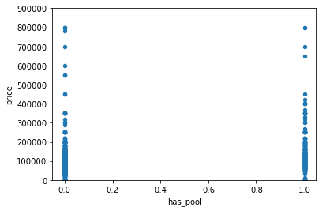

```python
#scatter plot Price vs other
data = pd.concat([clean_data['price'], clean_data['has_pool']], axis=1)
data.plot.scatter(x='has_pool', y='price', ylim=(0,900000));
```

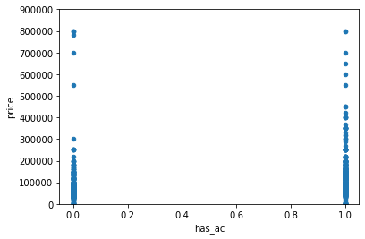

```python
#scatter plot Price vs other
data = pd.concat([clean_data['price'], clean_data['has_ac']], axis=1)
data.plot.scatter(x='has_ac', y='price', ylim=(0,900000));
```

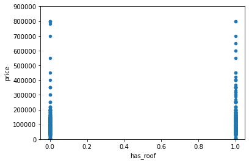

```python
#scatter plot Price vs other
data = pd.concat([clean_data['price'], clean_data['has_roof']], axis=1)
data.plot.scatter(x='has_roof', y='price', ylim=(0,900000));
```

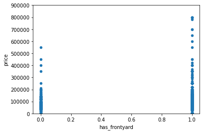

```python
#scatter plot Price vs other
data = pd.concat([clean_data['price'], clean_data['has_frontyard']], axis=1)
data.plot.scatter(x='has_frontyard', y='price', ylim=(0,900000));
```

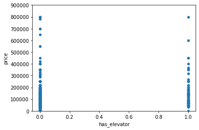

```python
#scatter plot Price vs other
data = pd.concat([clean_data['price'], clean_data['has_elevator']], axis=1)
data.plot.scatter(x='has_elevator', y='price', ylim=(0,900000));
```

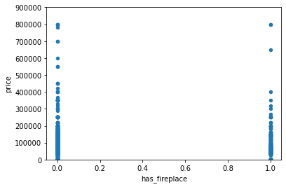

```python
#scatter plot Price vs other
data = pd.concat([clean_data['price'], clean_data['has_fireplace']], axis=1)
data.plot.scatter(x='has_fireplace', y='price', ylim=(0,900000));
```

#### House Price Prediction

Categorical variables require special attention in regression analysis because, unlike dichotomous or continuous variables, they cannot by entered into the regression equation just as they are. Instead, they need to be recoded into a series of variables which can then be entered into the regression model

```python
#Encode
#In the above data frame, we have a categorical variable, so we need to add dummy variables instead.
var_to_dummy = clean_data[['city']]
dummies = pd.get_dummies(data=var_to_dummy,drop_first=True) #this code added the dummy variable in form of 0 and 1, which is easy to interpret for the regression model.
clean_data.drop(columns=['city','district','front'],inplace=True)
# Drop column as it is now encoded
#data_df = data_df.drop('vehicleType',axis = 1)
#Join the encoded df
clean_data = clean_data.join(dummies)
clean_data.columns
#clean_data.shape
```

```
Index(['size', 'property_age', 'bedrooms_number', 'bathrooms_number',
       'livingrooms_number', 'kitchen_existence', 'garage_existence',
       'has_driver_room', 'has_maid_room', 'is_furnished', 'has_ac',
       'has_roof', 'has_pool', 'has_frontyard', 'has_basement', 'is_duplex',
       'has_elevator', 'has_fireplace', 'price', 'rooms_number',
       'house_worker_facilities_existence', 'city_ Dammam', 'city_ Riyadh',
       'city_ Jeddah'],
      dtype='object')
```

```python
import pandas as pd
from sklearn.model_selection import train_test_split
from matplotlib import pyplot as plt
```

```python
#the independent variables would be
X = clean_data.drop(['price','bedrooms_number','bathrooms_number','livingrooms_number'],axis=1) #As we will use the Created variable for the numbers of rooms instead
Y = clean_data['price']
x_train, x_test,y_train,y_test = train_test_split(X,Y,test_size =0.2)
```

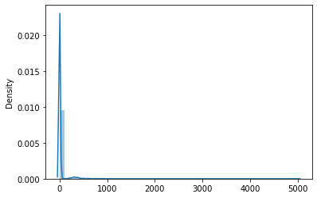

```python
#x_train.head()
sns.distplot(x_train);
```

```python
from sklearn.linear_model import LinearRegression
model = LinearRegression()
model.fit(x_train,y_train)
```

```
LinearRegression()
```

```python
from sklearn import metrics

def model_scores(true, predicted):
    mae = metrics.mean_absolute_error(true, predicted)
    mse = metrics.mean_squared_error(true, predicted)
    rmse = np.sqrt(metrics.mean_squared_error(true, predicted))
    r2_square = metrics.r2_score(true, predicted)
    print('MAE:', mae)
    print('MSE:', mse)
    print('RMSE:', rmse)
    print('R2 Square', r2_square , 'It means our model is accurate up to ',r2_square,'% of the time.')
    print('__________________________________')
```

```python
print("Training set score: {:.2f}".format(model.score(x_train, y_train)))
print("Test set score: {:.2f}".format(model.score(x_test, y_test)))
print("\n_____________________________________")
test_pred = model.predict(x_test)
train_pred = model.predict(x_train)

print('Test set evaluation:\n_____________________________________')
model_scores(y_test, test_pred)
print('Train set evaluation:\n_____________________________________')
model_scores(y_train, train_pred)
```

```
Training set score: 0.33
Test set score: 0.18

_____________________________________
Test set evaluation:
_____________________________________
MAE: 38515.906285163204
MSE: 8723528067.027695
RMSE: 93399.82905245434
R2 Square 0.17883389358260882 It means our model is accurate up to  0.17883389358260882 % of the time.
__________________________________
Train set evaluation:
_____________________________________
MAE: 37036.1988708246
MSE: 6011370876.326642
RMSE: 77533.03087282633
R2 Square 0.3278219477106088 It means our model is accurate up to  0.3278219477106088 % of the time.
__________________________________
```

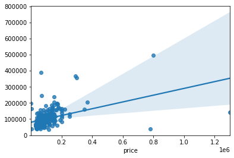

```python
sns.regplot(y_test,test_pred);
```

```python
import statsmodels.api as sm
X_train_Sm= sm.add_constant(x_train)
X_train_Sm= sm.add_constant(x_train)
ls=sm.OLS(y_train,X_train_Sm).fit()
print(ls.summary())
```

```
                            OLS Regression Results
==============================================================================
Dep. Variable:                  price   R-squared:                       0.328
Model:                            OLS   Adj. R-squared:                  0.317
Method:                 Least Squares   F-statistic:                     29.14
Date:                Fri, 19 Nov 2021   Prob (F-statistic):           1.09e-88
Time:                        15:57:19   Log-Likelihood:                -15416.
No. Observations:                1216   AIC:                         3.087e+04
Df Residuals:                    1195   BIC:                         3.098e+04
Df Model:                          20
Covariance Type:            nonrobust
=====================================================================================================
                                        coef    std err          t      P>|t|      [0.025      0.975]
-----------------------------------------------------------------------------------------------------
const                             -2.214e+04   1.89e+04     -1.173      0.241   -5.92e+04    1.49e+04
size                                142.4606      8.812     16.166      0.000     125.171     159.750
property_age                       -719.9282    305.086     -2.360      0.018   -1318.493    -121.364
kitchen_existence                  8169.3412   8400.710      0.972      0.331   -8312.442    2.47e+04
garage_existence                  -1492.5325   6980.154     -0.214      0.831   -1.52e+04    1.22e+04
has_driver_room                    -964.0403   1.18e+04     -0.081      0.935   -2.42e+04    2.23e+04
has_maid_room                      2263.5789   7548.595      0.300      0.764   -1.25e+04    1.71e+04
is_furnished                      -3169.6372   7086.928     -0.447      0.655   -1.71e+04    1.07e+04
has_ac                             2.416e+04   5265.086      4.588      0.000    1.38e+04    3.45e+04
has_roof                          -3742.9351   4959.337     -0.755      0.451   -1.35e+04    5987.041
has_pool                           2.072e+04   6670.639      3.106      0.002    7633.329    3.38e+04
has_frontyard                      1743.7821   6152.933      0.283      0.777   -1.03e+04    1.38e+04
has_basement                       4.074e+04   9690.982      4.204      0.000    2.17e+04    5.98e+04
is_duplex                         -3894.7084   5179.717     -0.752      0.452   -1.41e+04    6267.643
has_elevator                       3.656e+04   8872.621      4.121      0.000    1.92e+04     5.4e+04
has_fireplace                     -1.601e+04   6199.135     -2.583      0.010   -2.82e+04   -3848.084
rooms_number                       1830.9066   1210.861      1.512      0.131    -544.743    4206.556
house_worker_facilities_existence  1.318e+04   1.28e+04      1.027      0.305    -1.2e+04    3.84e+04
city_ Dammam                      -1225.7484   1.25e+04     -0.098      0.922   -2.58e+04    2.33e+04
city_ Riyadh                       1.955e+04   1.02e+04      1.908      0.057    -554.269    3.96e+04
city_ Jeddah                       1.588e+04   1.11e+04      1.435      0.151   -5828.482    3.76e+04
==============================================================================
Omnibus:                     1541.056   Durbin-Watson:                   2.014
Prob(Omnibus):                  0.000   Jarque-Bera (JB):           307710.167
Skew:                           6.522   Prob(JB):                         0.00
Kurtosis:                      79.832   Cond. No.                     4.98e+03
==============================================================================

Notes:
[1] Standard Errors assume that the covariance matrix of the errors is correctly specified.
[2] The condition number is large, 4.98e+03. This might indicate that there are
strong multicollinearity or other numerical problems.
```

```python
coeff_parameter = pd.DataFrame(model.coef_,X.columns,columns=['Coefficient'])
coeff_parameter
```

|  | Coefficient |
| --- | --- |
| size | 142.460565 |
| property_age | -719.928166 |
| kitchen_existence | 8169.341244 |
| garage_existence | -1492.532494 |
| has_driver_room | -964.040308 |
| has_maid_room | 2263.578873 |
| is_furnished | -3169.637185 |
| has_ac | 24156.322646 |
| has_roof | -3742.935118 |
| has_pool | 20720.797199 |
| has_frontyard | 1743.782055 |
| has_basement | 40737.147721 |
| is_duplex | -3894.708390 |
| has_elevator | 36560.528555 |
| has_fireplace | -16010.483107 |
| rooms_number | 1830.906613 |
| house_worker_facilities_existence | 13181.124159 |
| city_ Dammam | -1225.748388 |
| city_ Riyadh | 19546.820284 |
| city_ Jeddah | 15880.474202 |

The sign of each coefficient indicates the direction of the relationship between a predictor variable and the response variable. A positive sign indicates that as the predictor variable increases, the Target variable also increases. A negative sign indicates that as the predictor variable increases, the Target variable decreases.

```python
X = clean_data[['kitchen_existence','has_driver_room','has_fireplace','has_frontyard','has_ac','has_pool','has_elevator','has_basement','rooms_number','size','is_furnished','property_age','city_ Dammam','city_ Riyadh','city_ Jeddah']]
Y = clean_data['price']
x_train, x_test,y_train,y_test = train_test_split(X,Y,test_size =0.2)
```

#### In conclusion :

limitation :

- There is some important information the tenant cares about when renting a house and it highly affects the price but it doesn't exist in the provided data set, Such as whether the house is near to the services, schools, and entertainment venues.